R 입문자 · 실제 코드와 줄 번호 연결 · 다크모드

# 일반 활동과 공격 코드의 흐름부터 읽는 요약본

R 코드 다운로드

**JSON → 라벨 확인 → 표 변환 → 집단별 집계 → 비율 비교 → 그래프·CSV**  
로그인 전용 분석에서 확장한 AWS 활동 비교입니다. 자체 이름 붙은 함수는 value(), plot_comparison(), 그 안의 label() 세 개이며, vapply()의 익명함수들이 이벤트를 하나씩 처리합니다. 현재 실행 파일은 266줄(주석·빈 줄 포함)입니다.

## 먼저 보는 목적과 결과

일반 활동과 공격에서 어떤 API가 자주 나오는지 비교합니다. 데이터의 should_sample 라벨로 두 집단을 나누고 집단 크기 차이를 비율로 보정합니다. 기계학습 모델이나 자동 탐지기는 만들지 않습니다.

전체**4,216건**

일반 활동**3,675건**87.17%

공격**541건**12.83%

JSON 읽기**→**라벨 검사**→**표 만들기**→**건수·비율**→**그래프 그리기**→**파일 저장**→**

일반 활동은 PutObject(업로드) 42.31%, 공격은 GetObject(조회·다운로드) 86.14%가 가장 많습니다. 이 파일의 공격은 S3 시나리오 3종에 한정됩니다. 같은 API가 양쪽에 나타날 수 있으므로 API 이름만으로 공격을 단정하면 안 됩니다.

[데이터 출처·설명](https://github.com/ArielCyber/cloud_log_sampling) · [사용한 train_labeled_a.zip](https://github.com/ArielCyber/cloud_log_sampling/blob/main/TrainOn/train_labeled_a.zip)

제작자의 공격 라벨과 API 요청 성공·실패는 별개입니다. 실습 환경의 분포이며 일반 서비스의 평균 공격 비율이 아닙니다.

### RStudio 실행

compare_activity.R을 열고 Source를 누르면 집계·파일 저장·Plots 표시까지 실행합니다. 경로는 현재 Mac에 맞춰져 있습니다. 다른 컴퓨터로 옮길 때는 패키지·입력·출력 경로를 수정하세요.

## 변수·매개변수: 어떤 데이터를 받나요?

| 이름 | 역할 | 자료형·크기 | 예시 |
| --- | --- | --- | --- |
| x | value(x)의 입력 | 필드 값 하나 또는 NULL | "PutObject", NULL |
| e | 익명함수의 입력 | CloudTrail 이벤트 한 개 | e$should_sample, e$eventName |
| events | 원본 이벤트 목록 | list · 4,216개 | Records 배열을 R로 읽은 값 |
| valid_label | 라벨 검사 결과 | logical · 4,216개 | TRUE, TRUE, … |
| records | 분석용 표 | data.frame · 4,216행×7열 | event_id, time_utc, group, event, service, attack_name, api |
| groups / totals | 범주 순서 / 집단 건수 | character / table | 일반 활동·공격 / 3,675·541 |
| overview | 전체 구성 표 | data.frame · 2행×3열 | group, count, percent |
| tab | API별 건수 표 | table · 68행×2열 | 행 = 서비스/API, 열 = 일반 활동/공격 |
| percent | API 비율 표 | table · 68행×2열 | tab 각 열 / 그 집단 전체 × 100 |
| api_counts | CSV용 비교 표 | data.frame · 68행×5열 | API 이름과 두 집단의 건수·비율 |
| scenarios | 공격 유형 빈도표 | table · 3개 | 519, 18, 4 |
| type / kind | 그래프 선택 / 반복 값 | 문자열 하나 | overview, api, scenarios |
| pick / i / k | 선택 API 행 번호 / 표시 순서 / 원본 행 번호 | 정수 벡터 / 정수 하나 | pick[i]로 원본 API 위치 찾기 |
| g | 두 집단 반복 번호 | 1 또는 2 | 1 = 일반 활동, 2 = 공격 |
| x, y (label) | 글자의 배치 좌표 | 숫자 하나씩 | 가로·세로 0~1 좌표; value(x)와 별개 |
| text / width / height | 표시 문구 / 허용 공간 | 문자열 / 숫자 | 긴 글자라면 크기를 축소 |
| adj / col | 정렬 / 색 | 숫자 / 문자열 | 0 왼쪽, .5 가운데 / #색상 |
| old / size / limit | 기존 설정 / 글자 배율 / 막대 기준 최댓값 | list / 숫자 | 그래프 설정 복원과 크기 조절 |
| ns / nums / denominator | 범주 이름 / 건수 / 비율의 분모 | 벡터 / 벡터 / 숫자 | overview는 4,216, scenarios는 541 |

## 01. 입력 파일을 R 목록으로 읽기

파일 경로 → 이벤트 4,216개

fromJSON()은 JSON 글자를 R 객체로 해석합니다. simplifyVector = FALSE는 중첩 구조를 list로 유지합니다. 끝의 $Records는 문서의 Records 배열만 꺼냅니다. events는 파일 경로가 아니라 이벤트 여러 개를 담은 목록입니다. .libPaths()는 이 컴퓨터에 설치한 jsonlite를 찾을 경로를 추가합니다. output_dir는 입력 JSON과 결과 파일이 있는 폴더입니다.

**실제 코드 · 1–16행 (줄을 클릭하면 설명)**

**코드 줄을 눌러 보세요**

현재 실행 파일의 줄 번호와 연결됩니다.

## 02. value(x)와 라벨 검사

누락 값과 잘못된 라벨을 먼저 확인

value(x)는 필드 값 하나를 받아 문자열 하나를 돌려줍니다. x가 NULL이거나 길이가 1이 아니면 빈 문자열을 즉시 반환합니다. 예: value(NULL) → "", value("GetObject") → "GetObject". 길이 1인 NA를 빈칸으로 바꾸는 함수는 아닙니다. valid_label의 익명함수는 이벤트 하나 e를 받아 should_sample이 논리형·길이 1·NA 아님을 모두 만족하는지 검사합니다. &&는 왼쪽 조건이 거짓이면 오른쪽을 검사하지 않습니다. vapply()는 논리값 하나씩을 모아 4,216개짜리 벡터를 만듭니다. 하나라도 잘못되면 stop()으로 중단하여 누락 라벨을 일반 활동으로 오인하지 않게 합니다.

**실제 코드 · 17–39행 (줄을 클릭하면 설명)**

**코드 줄을 눌러 보세요**

현재 실행 파일의 줄 번호와 연결됩니다.

## 03. JSON 목록을 표로 바꾸기

events → records: 4,216행, 처음에는 6열

vapply(events, function(e) ..., character(1))에서 e는 매번 바뀌는 이벤트 하나입니다. character(1)은 출력이 문자열 하나여야 한다는 약속입니다. 각 호출이 만든 같은 길이의 벡터들을 data.frame()이 열로 묶습니다. event_id는 식별자, time_utc는 시각 문자열, event는 API 이름, service는 AWS 서비스명입니다. group 열은 should_sample = TRUE이면 공격, FALSE이면 일반 활동입니다. 데이터 제작자가 붙인 라벨을 읽는 것이며 새로운 공격을 예측하지 않습니다. attack_name은 공격 시나리오명이고 일반 기록에서는 보통 빈 문자열이 됩니다.

**실제 코드 · 40–54행 (줄을 클릭하면 설명)**

**코드 줄을 눌러 보세요**

현재 실행 파일의 줄 번호와 연결됩니다.

## 04. 일반 활동과 공격의 전체 구성

일반 활동 3,675건 / 공격 541건

groups는 열과 범주의 순서를 일반 활동 → 공격으로 고정합니다. factor(..., levels = groups)로 이 순서를 정하고 table()이 범주별 건수를 셉니다. as.integer()는 이름 붙은 빈도표에서 건수를 꺼냅니다. overview는 group·count·percent 세 열의 표입니다. 이 절의 percent는 전체 4,216건을 분모로 계산하므로 일반 활동 87.17%, 공격 12.83%가 됩니다. 뒤의 percent 변수는 별도로 만들어지는 API 비율 표이므로 이름의 위치를 구분해야 합니다.

**실제 코드 · 55–63행 (줄을 클릭하면 설명)**

**코드 줄을 눌러 보세요**

현재 실행 파일의 줄 번호와 연결됩니다.

## 05. 서비스·API별 건수와 집단 내부 비율

records → tab(68행×2열) → percent

paste()는 서비스명과 이벤트 이름을 합칩니다. 예: s3.amazonaws.com / PutObject. 서비스가 다른 동명 API를 섞지 않기 위한 키입니다. records에 api 열이 추가되어 최종 7열이 됩니다. table()의 행은 API, 열은 일반 활동·공격입니다. tab[, 1]은 일반 활동 열 전체이고 tab[, 2]는 공격 열 전체입니다. sweep(tab, 2, as.numeric(totals), "/")는 2번 차원인 열마다 각각 다른 분모(3,675와 541)로 나눕니다. 전체 4,216으로 나누는 식이 아닙니다. PutObject의 일반 비율은 1,555 / 3,675 × 100 = 42.31%, GetObject의 공격 비율은 466 / 541 × 100 = 86.14%입니다. api_counts는 모든 68개 API의 건수와 비율을 저장합니다.

**실제 코드 · 64–76행 (줄을 클릭하면 설명)**

**코드 줄을 눌러 보세요**

현재 실행 파일의 줄 번호와 연결됩니다.

## 06. 공격 시나리오 집계와 검산

공격 541건만 선택 → 세 시나리오

records$group == "공격"은 행마다 TRUE/FALSE를 만듭니다. 대괄호가 TRUE인 행의 attack_name만 남기고 table()이 시나리오별로 셉니다. sort(..., decreasing = TRUE)는 많은 순으로 정렬합니다. 여러 버킷 대량 조회 519건, 익명 S3 호출 18건, 단일 버킷 대량 조회 4건입니다. stopifnot()은 API 표의 합이 전체 행 수와 같은지, 시나리오 합이 공격 전체와 같은지 검사합니다. 틀리면 중단하지만 공격 라벨 자체가 올바른지 증명하는 검사는 아닙니다.

**실제 코드 · 77–86행 (줄을 클릭하면 설명)**

**코드 줄을 눌러 보세요**

현재 실행 파일의 줄 번호와 연결됩니다.

## 07. CSV와 JSON 파일 저장

집계 결과를 재사용 가능한 파일로

write.csv()는 표를 CSV로 기록합니다. file.path()는 폴더와 파일명을 연결하고 row.names = FALSE는 불필요한 행 번호 열을 빼 줍니다. UTF-8은 한글 인코딩입니다. write_json()은 전체·일반·공격 건수와 고유 eventID 수를 저장합니다. unname()은 이름 속성만 제거합니다. unique()는 고유 ID 수를 세는 데 쓰이며 실제 분석 행을 중복 제거하지는 않습니다. 같은 경로로 실행하면 기존 결과 파일을 덮어씁니다.

**실제 코드 · 87–117행 (줄을 클릭하면 설명)**

**코드 줄을 눌러 보세요**

현재 실행 파일의 줄 번호와 연결됩니다.

## 08. plot_comparison(type)와 label()

그래프 유형 선택 → 화면 준비 → 글자 크기 계산

plot_comparison()은 type으로 overview·api·scenarios 중 하나를 받습니다. match.arg()가 선택을 확인하며 생략하면 첫 항목 overview를 사용합니다. old에는 현재 그래프 설정을 저장하고 on.exit()으로 함수 종료 때 복원합니다. par()는 여백, 한 화면 한 그래프, 글꼴과 색을 설정합니다. plot.new()와 plot.window()는 가로·세로 0~1의 캔버스를 만듭니다. 안쪽 label()은 데이터의 좌표가 아니라 화면 배치 좌표 x·y, 표시할 문자열 text를 받습니다. width와 height는 글자를 넣을 공간이며, strwidth()/strheight()와 min()으로 크기를 줄여 겹침을 줄입니다. label은 plot_comparison 안에서만 정의되는 지역 함수입니다. switch()는 type에 맞는 제목을 선택합니다.

**실제 코드 · 118–162행 (줄을 클릭하면 설명)**

**코드 줄을 눌러 보세요**

현재 실행 파일의 줄 번호와 연결됩니다.

## 09. API 비교: 조건문과 이중 반복문

각 집단 상위 4개 → 합집합 6개 → API마다 막대 2개

type == "api"일 때만 이 경로가 실행됩니다. order()가 건수를 큰 순서로 나열할 행 번호를 구하고 head(..., 4)가 상위 4개를 고릅니다. unique(c(...))는 두 목록에 같이 등장한 API 번호를 한 번만 남기므로 현재 6개가 선택됩니다. pmax()는 각 API의 두 집단 비율 중 큰 값을 고르고 이를 기준으로 행을 정렬합니다. i는 화면에 표시할 첫째·둘째… API의 순서, k = pick[i]는 원래 68행 표에서의 행 번호입니다. 내부 g는 1(일반 활동), 2(공격)로 바뀌며 API당 두 막대를 그립니다. y는 두 막대를 조금 위아래로 나누고 end는 비율을 막대의 오른쪽 좌표로 바꿉니다. limit는 표시 대상 중 최대 비율로, 막대 크기 조절에만 쓰입니다. 표시되는 숫자는 percent 원값이므로 비율의 분모가 바뀌지 않습니다.

**실제 코드 · 163–208행 (줄을 클릭하면 설명)**

**코드 줄을 눌러 보세요**

현재 실행 파일의 줄 번호와 연결됩니다.

## 10. 전체 구성·공격 유형: else 분기

같은 막대 코드를 서로 다른 값으로 재사용

type이 api가 아니면 else 경로입니다. overview이면 ns에 두 집단 이름, nums에 3,675·541을 넣고, scenarios이면 시나리오 이름과 519·18·4를 넣습니다. for는 각 범주를 순회합니다. denominator는 overview에서 전체 4,216, scenarios에서 공격 541이므로 같은 막대 코드라도 퍼센트의 의미가 다릅니다. rect()는 사각형을 그립니다. label()로 건수와 비율을 씁니다. 마지막 invisible(api_counts)는 값을 반환하되 콘솔에 자동 출력하지 않습니다. 함수는 events·records·tab 같은 바깥 변수를 사용하므로 집계 부분을 먼저 실행해야 합니다.

**실제 코드 · 209–246행 (줄을 클릭하면 설명)**

**코드 줄을 눌러 보세요**

현재 실행 파일의 줄 번호와 연결됩니다.

## 11. 그래프를 PNG로 저장

overview → api → scenarios 순서로 파일 3개

kind는 반복할 때마다 그래프 유형 문자열 하나가 됩니다. png()를 열면 이후 그림은 파일에 기록됩니다. plot_comparison(kind)가 실제 그림을 그린 뒤 dev.off()가 파일 기록을 마무리합니다. width·height는 픽셀 수, res는 해상도입니다. type = "quartz"와 AppleGothic은 현재 Mac 환경에 맞춘 설정입니다. 다른 운영체제에서 실행하려면 장치·글꼴과 절대 경로를 조정해야 합니다.

**실제 코드 · 247–256행 (줄을 클릭하면 설명)**

**코드 줄을 눌러 보세요**

현재 실행 파일의 줄 번호와 연결됩니다.

## 12. 콘솔 출력과 RStudio 표시

통계 출력 → 대화형 환경에서만 화면 그래프

**실제 코드 · 257–266행 (줄을 클릭하면 설명)**

**코드 줄을 눌러 보세요**

현재 실행 파일의 줄 번호와 연결됩니다.

## 조건문·반복문 사전

| 조건 | 검사하는 것 | 참일 때 | 거짓일 때 |
| --- | --- | --- | --- |
| value의 if | NULL 또는 길이가 1이 아님 | 빈 문자열 반환 | 값을 문자열로 변환 |
| 라벨 검사의 && | 논리형·한 개·NA 아님 모두 충족 | 이벤트 검사 결과 TRUE | FALSE, 전체 검사에서 중단 |
| !all(valid_label) | 잘못된 라벨 하나 이상 | stop()으로 분석 중단 | 표 만들기 진행 |
| group의 if | should_sample = TRUE | 공격 | 일반 활동 |
| stopifnot 두 검사 | 합계가 원래 건수와 일치 | 그대로 다음 단계 | 오류로 중단 |
| type == "api" | API 비교 그래프 요청 | API별 이중 반복문 | 구성·시나리오 공통 코드 |
| g == 1 | 일반 활동 막대 | 세로 좌표 +.013 | 공격 막대: -.013 |
| type == "overview" | 전체 구성 그래프 | 이름·건수·분모 4,216 선택 | 공격 유형·분모 541 선택 |
| interactive() | RStudio 등 대화형 세션 | 화면 그래프 3종 표시 | PNG 저장 후 화면 표시 생략 |

### 반복은 어디서 일어날까요?

vapply()는 이벤트 4,216개를 각각 처리합니다. API 그래프의 바깥 for는 선택 API 6개를, 안쪽 for는 일반·공격 두 집단을 반복하므로 막대 자리 12개를 계산합니다. 전체 구성 그래프는 두 범주, 공격 유형 그래프는 세 범주를 반복합니다. 마지막 두 kind 반복은 파일용 그래프 3종과 화면용 그래프 3종입니다. 화면용 반복은 interactive()가 참일 때만 실행됩니다.

## R 기초 문법 사전

| 문법·함수 | 읽는 방법 |
| --- | --- |
| <- | 오른쪽 계산 결과에 왼쪽 이름을 붙입니다. |
| $ | 목록 또는 표에서 이름으로 필드를 꺼냅니다. |
| :: | 패키지 이름을 지정해 함수를 사용합니다. |
| function(x) | x를 입력받는 함수를 정의합니다. 정의와 호출은 다릅니다. |
| vapply(..., character(1)) | 원소마다 함수를 적용하고 문자열 하나씩 받는지 확인합니다. |
| && / \|\| / ! | 모두 참 / 하나라도 참 / 참·거짓 반전. &&와 \|\|는 단일 조건을 단락 평가합니다. |
| == / != | 같은지 / 다른지 비교합니다. 대입 기호와 다릅니다. |
| tab[, 1] | 행은 모두 선택하고 첫째 열을 꺼냅니다. |
| totals[["공격"]] | 이름이 공격인 원소 한 개를 꺼냅니다. |
| factor() / table() | 범주와 순서를 정하고 범주별 빈도를 셉니다. |
| sweep(..., 2, ..., "/") | 행렬의 열마다 다른 분모를 적용합니다. 2는 둘째 열이 아니라 열 방향입니다. |
| order() / head() / unique() | 정렬할 위치 / 앞부분 / 중복 없는 값. |
| for (...) { ... } | 값을 하나씩 바꾸며 중괄호 안을 반복합니다. |
| seq_along() | 대상 길이에 맞는 1, 2, … 번호를 만듭니다. |
| sprintf("%.1f%%", x) | 소수점 한 자리 숫자와 % 기호를 문자열로 만듭니다. |
| on.exit() / invisible() | 함수 종료 시 정리 예약 / 값은 반환하되 자동 출력은 생략. |
| png() / dev.off() | 파일 그림 장치를 열고 닫아 저장을 완료합니다. |

## 데이터가 바뀌는 모습

아래 JSON은 구조를 설명하기 위해 줄인 예시입니다. 실제 원본 전체를 대체하는 입력은 아닙니다.

```
{"Records": [
  {"eventName": "GetObject", "eventSource": "s3.amazonaws.com",
   "should_sample": true, "attack_name": "MassGetMultipleBuckets"}
]}
```

events: 이벤트 목록**→**e: 이번 이벤트 한 개**→**e$should_sample: TRUE**→**group: 공격**→**tab의 GetObject/공격 칸 +1

실제 데이터의 공격 GetObject는 466건입니다. 공격 전체 541건으로 나눠 86.14%를 얻습니다. 이 수치는 “GetObject 중 공격일 확률”이 아니라 “공격 기록 중 GetObject가 차지하는 비율”입니다.

### 원본을 바로 세면 왜 불편할까요?

JSON은 이벤트마다 중첩 목록을 꺼내야 합니다. records라는 표로 바꾸면 각 이벤트를 한 행으로 맞추고 group·event·service 열을 사용해 쉽게 집계할 수 있습니다. 이 변환은 분석용 표 정리이며 데이터베이스의 정규화 설계를 뜻하지는 않습니다.

## 발표용 설명과 예상 질문

“이 프로젝트는 공개 AWS CloudTrail 기록 4,216건을 일반 활동과 공격으로 구분해 API 사용 패턴을 비교했습니다. 집단 크기가 다르기 때문에 건수뿐 아니라 각 집단 내부 비율을 계산했습니다. 일반 활동에서는 업로드, 공격에서는 다운로드 API의 비중이 높았습니다. 다만 기존 라벨을 비교한 결과이며 API 이름 하나로 공격 여부를 단정하지는 않습니다.”

### 왜 실패 기록을 공격으로 분류하지 않나요?

일반 사용자의 실수도 실패할 수 있고, 공격자의 작업도 성공할 수 있습니다. 이 분석은 요청 결과가 아니라 제작자의 should_sample 라벨을 사용합니다.

### 왜 541건을 기준으로 나누나요?

공격 집단에서 어떤 행동이 많이 발생하는지 비교하려는 목적이기 때문입니다. 일반 활동은 3,675건, 공격은 541건을 분모로 사용합니다.

### 공격을 자동으로 탐지했나요?

아닙니다. 이미 라벨이 있는 데이터를 설명·비교하는 분석입니다. 새로운 기록을 분류하는 모델의 성능은 평가하지 않았습니다.

### 데이터를 줄이거나 공격 비율을 맞췄나요?

아닙니다. 원본 4,216건을 모두 사용했습니다. 그래프만 각 집단 상위 4개 API의 합집합을 보여주며 전체 API 집계는 CSV에 저장합니다. 중복 eventID 수는 따로 기록하지만 행을 제거하지 않습니다.

## 결과 그래프와 파일

### 전체 구성

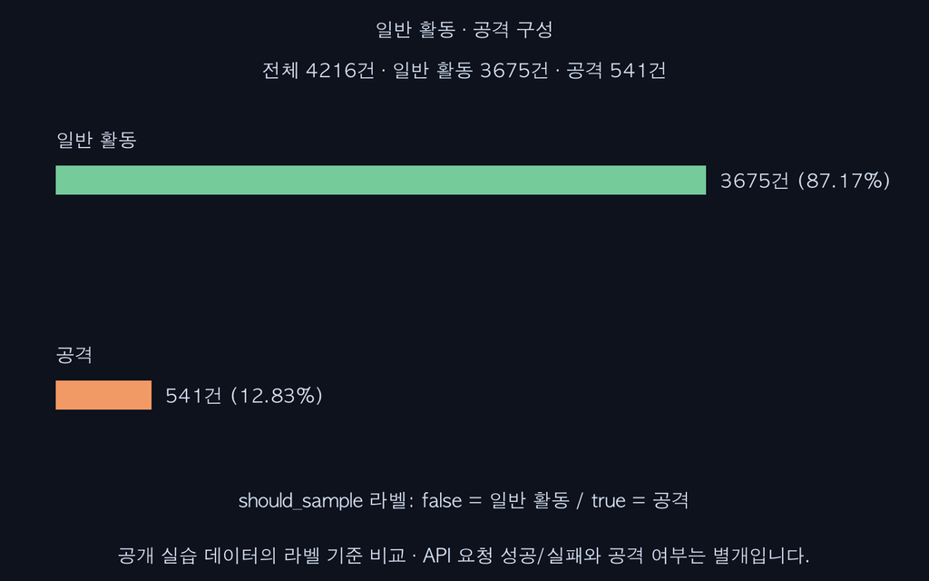

### 집단별 API 비율

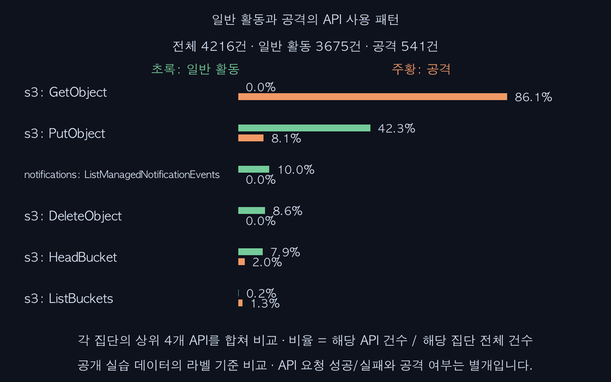

### 공격 시나리오

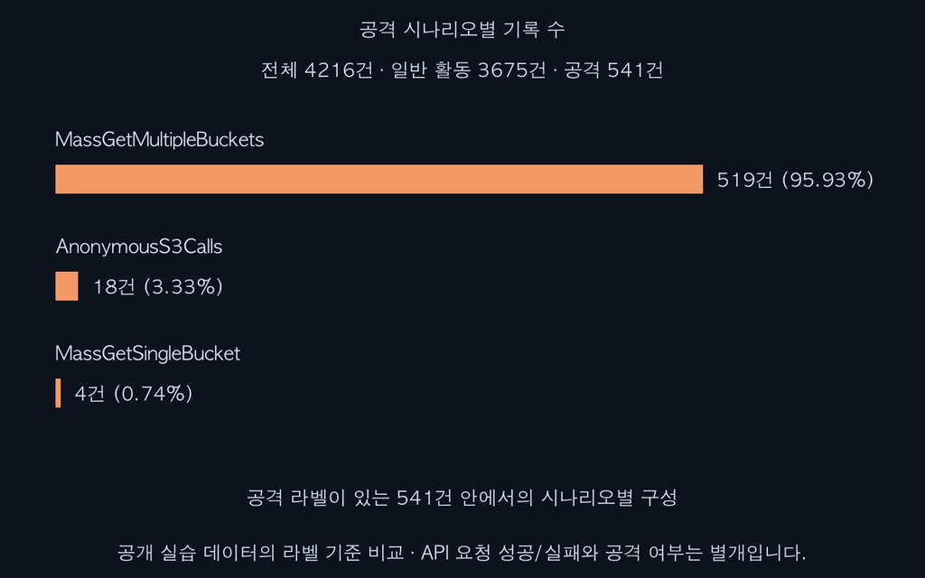

전체 구성 CSV · 모든 API 비교 CSV · 공격 유형 CSV · 검산용 JSON